# Visualizacion de datos usando ggplot2

# Mini ejercicio

como le agregariamos los colores a este ejercicio en vez de los predetermiandos?

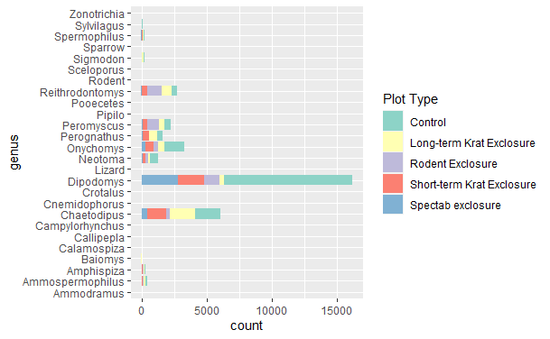

Aqui les paso otra manera rapida y facil de elegir varios colores sin pensar mucho: [Rbrewer](https://www.datanovia.com/en/blog/the-a-z-of-rcolorbrewer-palette/)

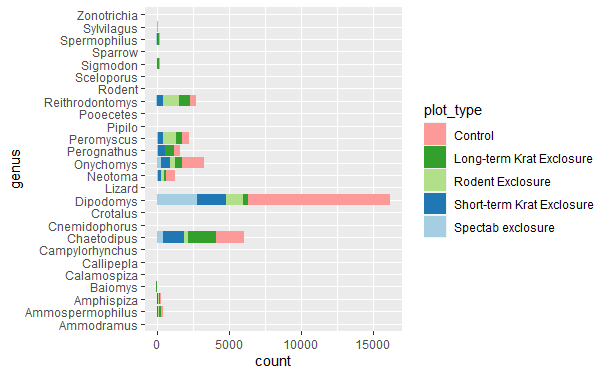

sin embargo, ademas de los colores el principal problema de este grarfico es la alta diferencia entre la abundancia de *Dipodomys* y el resto de las especies. Para solucionarlo aprenderemos a hacer cortes o breaks en los ejes:

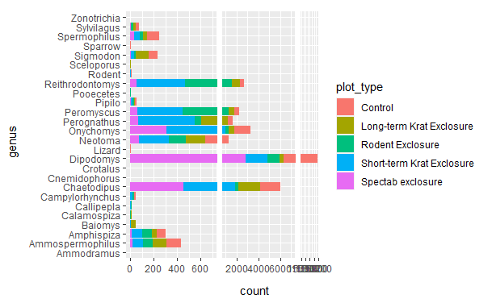

Aunque esta muy bien contar el numero generos de ratoncitos que tenemos, usualmente los graficos de barras son usados para representar los valor4es de una poblacion, para ello:

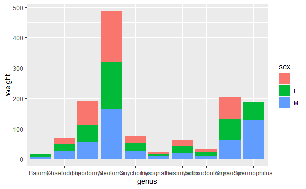

Tambien se puede hacer con geom_col:

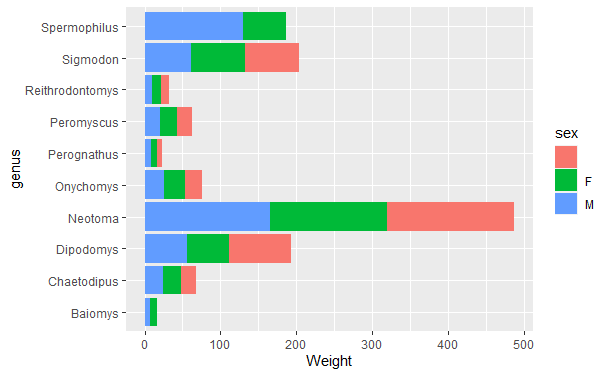

Lo ultimo que le faltaria a nuestro grafico de barras son las barras de error:

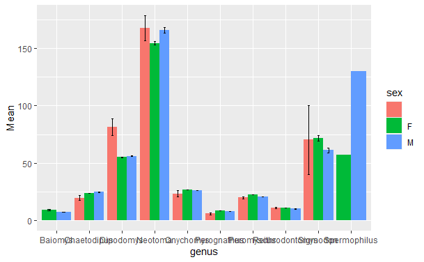

## Ejercicio

Hagan una grafica con la longitud del sepalo de la tabla iris. Separen por especie, saquen la media y grafiquen incluyendo barras de error. Como siempre modifiquen colores y etiquetas de los ejes y leyendas.

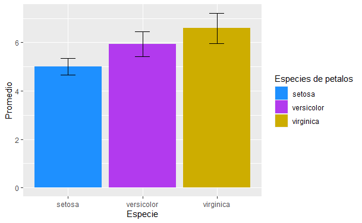

# Grafico circular

Curiosamente ggplot no tiene una geometria especial para hacer graficos circulares o de pay, sin embargo, para poder realizar estos graficos se tiene que modificar el geom_bar:

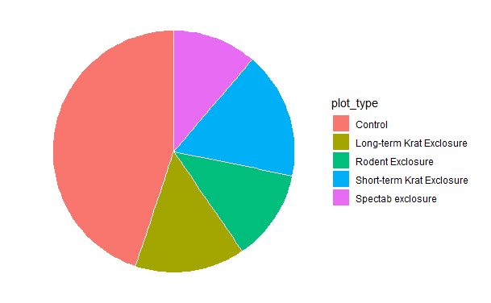

En realidad el codigo para este tipo de graficos no es tan complicado. Lo mas dificil es tener la tabla en el formato correcto. Casi no van a usar este tipo de formato pero usualmente los datos que usen tendrian que estar en proporciones o porcentajes o poder convertise a los mismos.

# Añadiendo significancia

## Por grupos

Como vimos durante la seccion estadistica de nuestro curso las diferencias estadisticas crean grupos que se pueden representar con letras para ello podemos usar la funcion annotate.

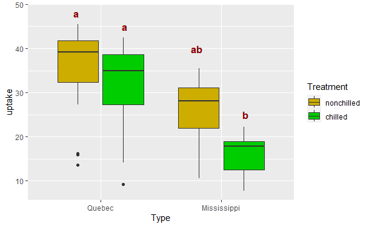

## Barras de diferencias estadisticas

Sin embrgo, muchas veces tambien conviene agregar mas inforamcion sobre dichas diferenciaws. Para ello usamos el paquete ggsignif. Este parquee nos ayuda a agregar especificamente las comparaciones entre cada tratamiento.

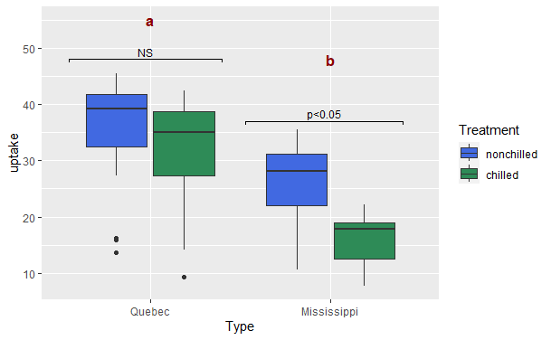

## Ejercicio final

Carguen nuevamente sus graficos de comp_soils y van a crear dos graficos: uno agregando grupos con letras y otro con barras de diferencias. Ahorita haganlo a ojo no necesario que calculen las diferencias estadisticas reales.

Presentar los graficos uno a lado de otro usando patchwork.

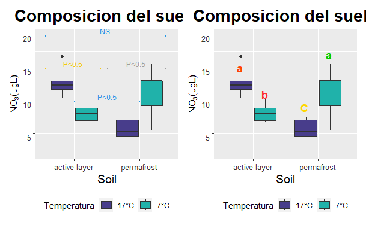